# Shiny Autocomplete

Sascha Coridun  
March 2017

A word prediction and completion app [(link)](https://saschac.shinyapps.io/shinyAutocomplete/), programmed in R Shiny, source code on [Github](https://github.com/SaschaC/capstone)

Created as the [Capstone Project for the Datascience Coursetrack on Coursera](https://www.coursera.org/learn/data-science-project)

### App description

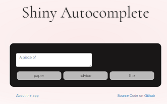

**Features:**

- Word prediction AND completion
- Three prediction buttons update as you type!
- Fast performance through caching and binary search

**How it was made:**

- I sampled a total of 300,000 lines from blogs, Twitter, and news articles and normalized the text removing punctuation and digits.
- I computed frequency counts of ~3.02 Million 3-grams (only those 3-grams with the 5,000 most frequent words in the sample; token coverage: ~87%).
- Based on the 3-gram frequency counts, the app predicts predicts words using Stupid Backoff ([Jurafsky D., Martin J.H., 2014. Ch4, pp. 19](https://lagunita.stanford.edu/c4x/Engineering/CS-224N/asset/slp4.pdf)). It computes bigram and unigram frequencies from the 3-gram frequencies on-the-fly.

### Functionality

**How the app works:**

1. User inputs words
2. App decides whether to *predict* new word or *complete* current word:
   - If a space ends the input, *predict*: App calculates the probabilities of 5,000 words and *caches* results
   - If no space ends the input, *complete*: App finds words in the cached results that match the current word at their beginnings
3. Prediction buttons show the three most probable words  
   **How to use the app:**

It takes ~5 seconds until the app has been fully launched. Now, simply type away and click the prediction buttons for autocompletion. Just like in a smartphone (well, almost)!

### The algorithm: Description

Stupid Backoff ([Jurafsky D., Martin J.H., 2014. Ch4, pp. 19](https://lagunita.stanford.edu/c4x/Engineering/CS-224N/asset/slp4.pdf)) assigns a probability to the occurrence of a word given the preceding words. The probability *S* of a word *w* at position *i* is calculated as:

\[ S(w_i|w^{i-1}_{i-k+1}) = \begin{cases} \frac {count(w_i)} {count(w_{i-k+1}^{i-1})} & \text{if count}(w^i_{i-k+1}) > 0 \\ \lambda S(w_i|w^{i-1}_{i-k+2}) & \text{otherwise} \end{cases} \]

The app uses 3-grams, so k=3. Importantly, when a higher order n-gram has a zero count, the algorithm backs off to the next lower order n-gram weighed by a fixed value \( \lambda \) (set to 0.4).

**Example:** the input is “piece of”. The probability of “cake” as being the next word is calculated as:

\[ S(\text{cake}|\text{piece of}) = \begin{cases} \frac {count(\text{piece of cake})} {count(\text{piece of})} & \text{if count}(\text{piece of cake}) > 0 \\ \lambda S(\text{cake}|\text{of}) & \text{otherwise} \end{cases} \]

If the count of “of cake” were zero, the algorithm terminates in the unigram probability which is \( S\frac{count(\text{cake})}{N} \), where *N* is the overall sum of unigram counts.

### The algorithm: Step-by-step example

User inputs “piece of ”:

- Input is normalized, non-alphanumeric characters are removed and all characters converted to lower case. Sentence beginnings are converted to “0 0”
- The algorithm searches the ~3.02 Million 3-gram frequencies. It uses [fast binary search with keys](https://cran.r-project.org/web/packages/data.table/vignettes/datatable-keys-fast-subset.html) for table subsetting.
- Backoff procedure:
  - **3-gram matching:** All 3-grams starting with “piece of” are selected. Trigram maximum likelihood estimates (MLE) and overall score are computed for every word that occurs as third word of the selected trigrams.
  - **Bigram matching:** Bigram frequency counts are computed by summarizing over all trigrams with “of” as second word. Bigram MLE and overall scores are computed for every word that occurs as the second word in the selected bigrams and that has not received a score in the previous step.
  - **Unigram matching:** Unigram frequency counts are computed by summarizing over all trigrams that contain those words as third words that have not received a score in the previous two steps. For these words, unigram MLE and overall scores are computed.
- Results are cached and the 3 words with the highest scores are selected as output.